# Health Insurance data

#### This project is designed to investigate patterns and relationships between the total amount of money charged by an insurance company to customers and other factors that might influence those charges. The data was taken from www.kaggle.com. I plan on using data visualization to ascertain a level of knowledge about feature behaviour. I then will investigate which features are important whilst also producing regression models for the prediction of charges given the input features.

```python
import pandas as pd
import numpy as np

import matplotlib.pyplot as plt
import seaborn as sns
%matplotlib inline

import pandas as pd
import numpy as np
import warnings
warnings.filterwarnings('ignore')
# For Notebooks
```

```python
df = pd.read_csv('D:\Python\Insight\insurance project\insurance.csv')
```

```python
df.head()
```

|  | age | sex | bmi | children | smoker | region | charges |
| --- | --- | --- | --- | --- | --- | --- | --- |
| 0 | 19 | female | 27.900 | 0 | yes | southwest | 16884.92400 |
| 1 | 18 | male | 33.770 | 1 | no | southeast | 1725.55230 |
| 2 | 28 | male | 33.000 | 3 | no | southeast | 4449.46200 |
| 3 | 33 | male | 22.705 | 0 | no | northwest | 21984.47061 |
| 4 | 32 | male | 28.880 | 0 | no | northwest | 3866.85520 |

```python
df.info()
```

```
<class 'pandas.core.frame.DataFrame'>
RangeIndex: 1338 entries, 0 to 1337
Data columns (total 7 columns):
age         1338 non-null int64
sex         1338 non-null object
bmi         1338 non-null float64
children    1338 non-null int64
smoker      1338 non-null object
region      1338 non-null object
charges     1338 non-null float64
dtypes: float64(2), int64(2), object(3)
memory usage: 73.2+ KB
```

```python
df.describe()
```

|  | age | bmi | children | charges |
| --- | --- | --- | --- | --- |
| count | 1338.000000 | 1338.000000 | 1338.000000 | 1338.000000 |
| mean | 39.207025 | 30.663397 | 1.094918 | 13270.422265 |
| std | 14.049960 | 6.098187 | 1.205493 | 12110.011237 |
| min | 18.000000 | 15.960000 | 0.000000 | 1121.873900 |
| 25% | 27.000000 | 26.296250 | 0.000000 | 4740.287150 |
| 50% | 39.000000 | 30.400000 | 1.000000 | 9382.033000 |
| 75% | 51.000000 | 34.693750 | 2.000000 | 16639.912515 |
| max | 64.000000 | 53.130000 | 5.000000 | 63770.428010 |

#### Data shows to be clean (ie no missing values)

## Client gender

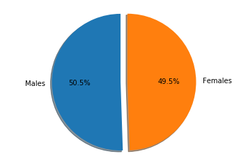

```python
labels = 'Males', 'Females'

malesn = len((df[df['sex']=='male'])) / len(df)
femalesn = len((df[df['sex']=='female'])) / len(df)

sizes = [malesn, femalesn]
explode = (0, 0.1)  # only "explode" the 2nd slice (i.e. 'Hogs')

fig1, ax1 = plt.subplots()
ax1.pie(sizes, explode=explode, labels=labels, autopct='%1.1f%%',
        shadow=True, startangle=90)
ax1.axis('equal')  # Equal aspect ratio ensures that pie is drawn as a circle.

plt.show()
```

#### There seems to be a close 50-50 split in gender between males and females

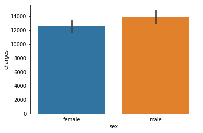

```python
sns.barplot(x='sex',y='charges',data=df)
```

#### Males paid more on avergae in charges than females.

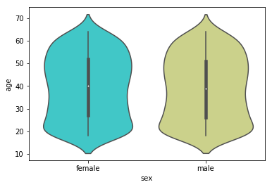

```python
sns.violinplot(x="sex", y="age", data=df,palette='rainbow')
```

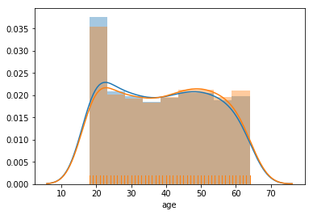

```python
sns.distplot(df.loc[df['sex'] == 'male', 'age'],rug=True)
sns.distplot(df.loc[df['sex'] == 'female', 'age'],rug=True)
```

#### Similar average age between sexes as seen by the above two charts. The distribution is very smilar between males and females but is not gaussian and shows a tendency towards a bi-modal distriubtion with most clients being less than 25 and a second maximum around 50 years of age

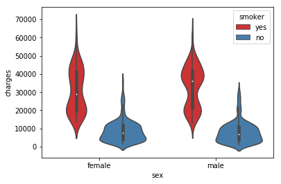

```python
sns.violinplot(x="sex", y="charges", data=df,hue='smoker',palette='Set1')
```

#### Our first inclination of how the relationship between gender and charges with respect to smoking is shown above. It shows regardless of gender, you are more likely to pay higher fees if you smoke compred to if you do not. Furthermore, there are slight differences in the distributions between male and female smokers, where on average males are more likely to pay higher fees if the smoke

# Smokers be warned

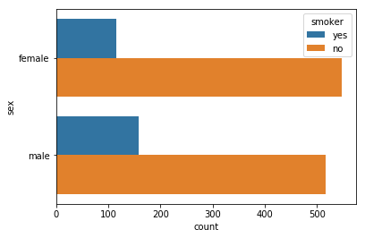

```python
ax = sns.countplot(y="sex", hue="smoker", data=df)
```

#### More men smoke compared to woman. Below shows the breakdown percentage wise.

```python
fs = len(df[(df['sex'] == 'female') & (df['smoker'] == 'yes')]) / len(df[df['sex'] == 'female'])

ms = len(df[(df['sex'] == 'male') & (df['smoker'] == 'yes')]) / len(df[df['sex'] == 'male'])

print('% number of females that smoke: ' + str(fs*100))
print('% number of males that smoke: ' + str(ms*100))
```

```
% number of females that smoke: 17.371601208459214
% number of males that smoke: 23.5207100591716
```

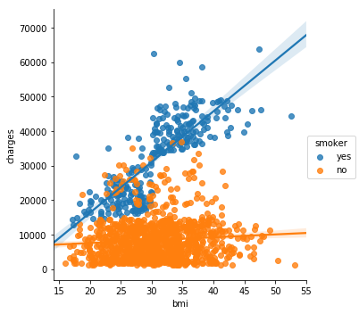

```python
sns.lmplot(x='bmi', y='charges', hue='smoker', data=df, fit_reg=True)
```

#### It can be seen that if you are a smoker, you will be charged higher. There is a strong linear trend in the data for smokers in regards to BMI. You smoke and your obese, you're gonna pay higher charges, plain and simple. More men smoke more than woman (although we are not told how much they smoke) and will have a higher total charge than females as seen by violin plot in previous section

# The impact of children

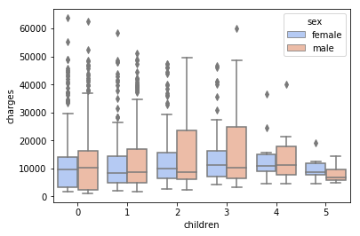

```python
sns.boxplot(x="children", y="charges", hue="sex",data=df, palette="coolwarm")
```

#### Here we can see the impact of children on gender wrt charges. On average there is little change in the median (per sex) wrt to the number of children in the family. If you are a male, you are more likely to pay on average more than say a male with two children. However, there seem to be more extreme cases (shown by the longer tails) of paying more charges if you have 2 or 3 children than compared to 0 and 1 or > 3 children

```python
for i in range(1,6):

    print(str(i) +  ' child: ' + str(len(df[(df['sex']=='male') & (df['children'] == i)])))
```

```
1 child: 166
2 child: 121
3 child: 80
4 child: 14
5 child: 10
```

#### There are few samples for 4 or more kids so statistics are not very robust. Typically want 30 or more samples before robustness starts to be more impactful

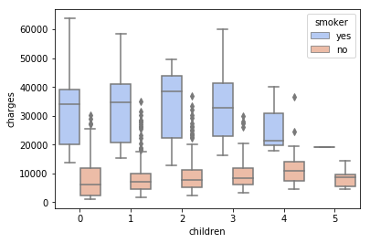

```python
sns.boxplot(x="children", y="charges", hue="smoker",data=df, palette="coolwarm")
```

#### Here i show the effect of children and charges but splitting data in terms of smokers or no smokers. In all cases smokers are paying more

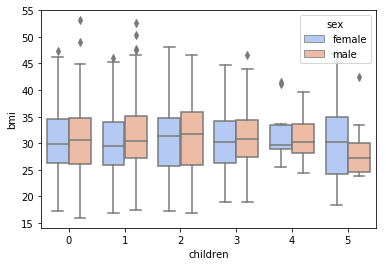

```python
sns.boxplot(x="children", y="bmi", hue="sex",data=df, palette="coolwarm")
```

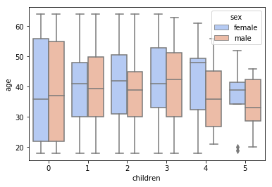

```python
sns.boxplot(x="children", y="age", hue="sex",data=df, palette="coolwarm")
```

#### Age as a function of number of children split on gender. No obvious reuslts here yet

# How does BMI impact?

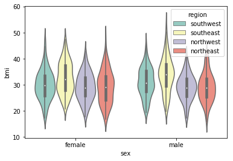

```python
sns.violinplot(x="sex", y="bmi", data=df,hue='region',palette='Set3')
```

#### Here, BMI and gender are shown but are split based on region. For both sexes, people from the southest have the largest BMI. Men are overall more over weight than woman. People from the northwest and northeast show the lowest BMIs. The distributions are fairly evenly spread around median values although some (like femal southeast) show a slight bimodal distribution.

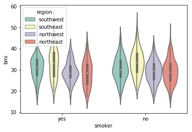

```python
sns.violinplot(x="smoker", y="bmi", data=df,hue='region',palette='Set3')
```

#### Similar to the above, except this is in comparison to smokers or not. This plot shows a similar result to the BMI vs sex plot

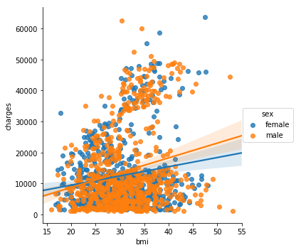

```python
sns.lmplot(x='bmi', y='charges', hue='sex', data=df, fit_reg=True)
```

#### no clear clustering here, but based on BMI and gender, men are typically paying higher charges per unit change in BMI

# More on charges

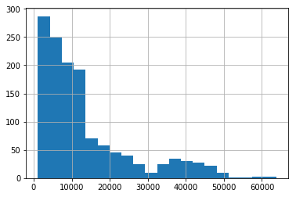

```python
df['charges'].hist(bins=20)
```

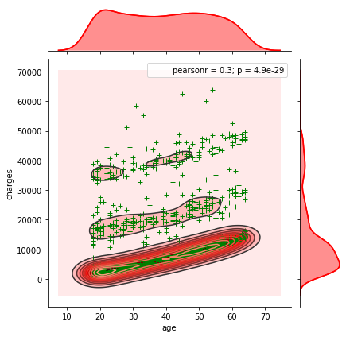

```python
g = sns.jointplot(x="age", y="charges", data = df,kind="kde", color="r")
g.plot_joint(plt.scatter, c="g", s=30, linewidth=1, marker="+")
g = g.plot_joint(sns.kdeplot, cmap="Reds_d")
g = g.plot_marginals(sns.kdeplot, color="r", shade=True)
```

#### Here I am compring age and see how charges are related. There appear to be three different clusters of data, with the most dense being the bottom level. So what are these clusters and are they related to smokers, BMI, children etc..

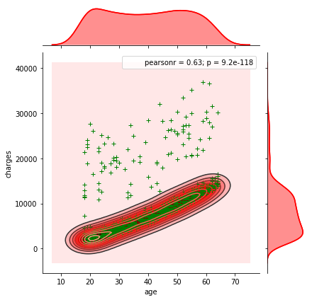

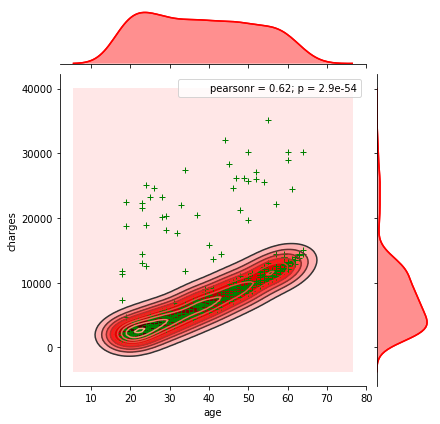

```python
g = sns.jointplot(x="age", y="charges", data = df[(df.smoker == 'no')],kind="kde", color="r")
g.plot_joint(plt.scatter, c="g", s=30, linewidth=1, marker="+")
g = g.plot_joint(sns.kdeplot, cmap="Reds_d")
g = g.plot_marginals(sns.kdeplot, color="r", shade=True)

g = sns.jointplot(x="age", y="charges", data = df[(df.smoker == 'no') & (df.bmi <30)],kind="kde", color="r")
g.plot_joint(plt.scatter, c="g", s=30, linewidth=1, marker="+")
g = g.plot_joint(sns.kdeplot, cmap="Reds_d")
g = g.plot_marginals(sns.kdeplot, color="r", shade=True)
```

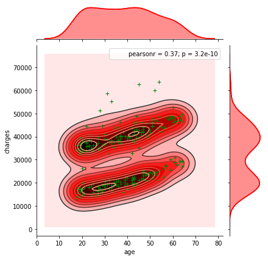

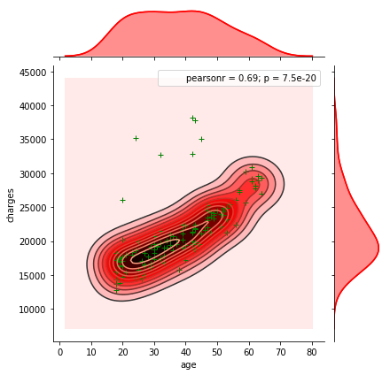

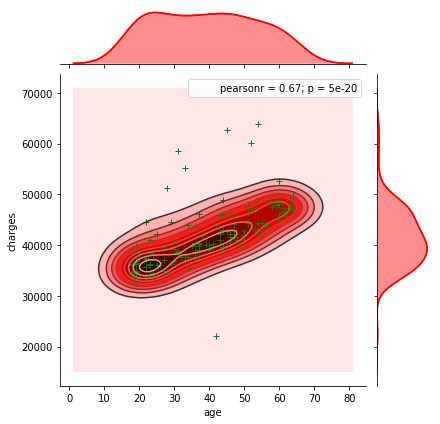

```python
g = sns.jointplot(x="age", y="charges", data = df[(df.smoker == 'yes')],kind="kde", color="r")
g.plot_joint(plt.scatter, c="g", s=30, linewidth=1, marker="+")
g = g.plot_joint(sns.kdeplot, cmap="Reds_d")
g = g.plot_marginals(sns.kdeplot, color="r", shade=True)

g = sns.jointplot(x="age", y="charges", data = df[(df.smoker == 'yes') & (df.bmi <30)],kind="kde", color="r")
g.plot_joint(plt.scatter, c="g", s=30, linewidth=1, marker="+")
g = g.plot_joint(sns.kdeplot, cmap="Reds_d")
g = g.plot_marginals(sns.kdeplot, color="r", shade=True)

g = sns.jointplot(x="age", y="charges", data = df[(df.smoker == 'yes') & (df.bmi >=30)],kind="kde", color="r")
g.plot_joint(plt.scatter, c="g", s=30, linewidth=1, marker="+")
g = g.plot_joint(sns.kdeplot, cmap="Reds_d")
g = g.plot_marginals(sns.kdeplot, color="r", shade=True)
```

#### These plots show charges as a function of smokers (top) and smokers with a BMI <30 (middle) and smokers with BMI >30 (bottom). The top plot shows that there is clearly a bomidal distribution of smokers when it comes to charges. Which has also been seen earlier and seems to be seperated using a BMI of 30. These clusters are seperated using BMI either larger or smaller than 30

#### From an insurers prespective, I would be wanting to help these higher risk groups (to help firstly them for health reasons), but also minimize the amount of money paid out. It would seem that both smoking, BMI are large factors to large payouts, but lets us see if we can capture the importance of each features. By doing this, we could focus on specific groups to help lead to a healthier life style

# Random forest regressor

### Here, I want to be able to predict charges given our input features using multivariate random forest regressor

```python
df.smoker.replace(('yes', 'no'), (1, 0), inplace=True)
df.sex.replace(('male', 'female'), (1, 0), inplace=True)
regions= pd.get_dummies(df['region'])
df1 = pd.concat([df,regions],axis=1)
df1.drop(['region'],axis=1, inplace=True)
df1.head()
```

|  | age | sex | bmi | children | smoker | charges | northeast | northwest | southeast | southwest |
| --- | --- | --- | --- | --- | --- | --- | --- | --- | --- | --- |
| 0 | 19 | 0 | 27.900 | 0 | 1 | 16884.92400 | 0 | 0 | 0 | 1 |
| 1 | 18 | 1 | 33.770 | 1 | 0 | 1725.55230 | 0 | 0 | 1 | 0 |
| 2 | 28 | 1 | 33.000 | 3 | 0 | 4449.46200 | 0 | 0 | 1 | 0 |
| 3 | 33 | 1 | 22.705 | 0 | 0 | 21984.47061 | 0 | 1 | 0 | 0 |
| 4 | 32 | 1 | 28.880 | 0 | 0 | 3866.85520 | 0 | 1 | 0 | 0 |

#### hot enconded region, and also made sex and smoker binary

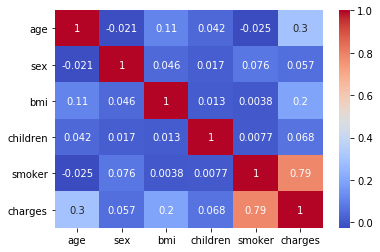

```python
sns.heatmap(df.corr(),cmap='coolwarm',annot=True)
```

#### This correlation plot shows the correlations between each variable. We see that smokers. BMI, and age have the largest correlations with charges. We also can see that the correlations with each other are low, which is a good sign concerning multi co-linearity purposes and their impact on regression.

```python
df2 = df1.copy()

targets = df1['charges']

df1.drop(['charges'],axis=1, inplace=True)


features = df1
```

#### Set up features (independent variables) and target (dependent variable)

```python
from sklearn.preprocessing import StandardScaler
from sklearn.model_selection import train_test_split


X_train, X_test, y_train, y_test = train_test_split(features, targets, train_size=0.7)

scaler = StandardScaler().fit(X_train)

X_train_scaled = pd.DataFrame(scaler.transform(X_train), index=X_train.index.values, columns=X_train.columns.values)
X_test_scaled = pd.DataFrame(scaler.transform(X_test), index=X_test.index.values, columns=X_test.columns.values)
```

#### Create a training and test set for the input data

```python
from sklearn.ensemble import RandomForestRegressor
rf = RandomForestRegressor(n_estimators=500, oob_score=True, min_samples_split=2, min_samples_leaf=1, random_state=0)
rf.fit(X_train, y_train)
```

```
RandomForestRegressor(bootstrap=True, criterion='mse', max_depth=None,
           max_features='auto', max_leaf_nodes=None,
           min_impurity_decrease=0.0, min_impurity_split=None,
           min_samples_leaf=1, min_samples_split=2,
           min_weight_fraction_leaf=0.0, n_estimators=500, n_jobs=1,
           oob_score=True, random_state=0, verbose=0, warm_start=False)
```

```python
from sklearn.metrics import r2_score
from scipy.stats import spearmanr, pearsonr
predicted_train = rf.predict(X_train)
predicted_test = rf.predict(X_test)
test_score = r2_score(y_test, predicted_test)
spearman = spearmanr(y_test, predicted_test)
pearson = pearsonr(y_test, predicted_test)
print(f'Out-of-bag R-2 score estimate: {rf.oob_score_:>5.3}')
print(f'Test data R-2 score: {test_score:>5.3}')
print(f'Test data Spearman correlation: {spearman[0]:.3}')
print(f'Test data Pearson correlation: {pearson[0]:.3}')
```

```
Out-of-bag R-2 score estimate: 0.848
Test data R-2 score:  0.83
Test data Spearman correlation: 0.845
Test data Pearson correlation: 0.911
```

#### Our training and test scores are fairly similar which is good as it means that we are finding a good trade off between bias in the traning set and overall variance between the training and test sets (ie, we are not over or underfitting the data). The R^2 value is stating that the features we are using help explain about 80-85% of the variation of the overall charges. There is another 15-20% of variation that is not accounted for by these features.

```python
rf.feature_importances_
```

```
array([0.13286553, 0.00530178, 0.20026284, 0.02189229, 0.62383184,
       0.00601176, 0.00365138, 0.00311414, 0.00306842])
```

```python
feature_importances = pd.DataFrame(rf.feature_importances_,index = X_train.columns,columns=['importance']).sort_values('importance', ascending=False)
feature_importances
```

|  | importance |
| --- | --- |
| smoker | 0.623832 |
| bmi | 0.200263 |
| age | 0.132866 |
| children | 0.021892 |
| northeast | 0.006012 |
| sex | 0.005302 |
| northwest | 0.003651 |
| southeast | 0.003114 |
| southwest | 0.003068 |

#### whilst we saw that children do have an influence on charges from the data visualization, especially on bmi, we can see that overall it can only be accountable for about 2%. Gender and location are fairly insignificant as weights,

#### However, which features are significant and which are not for the prediction of charges? We would need to look at P-values to find out

# Classic multi-variate least squares

```python
from sklearn.model_selection import train_test_split
from sklearn.linear_model import LinearRegression
from sklearn import metrics
from sklearn.metrics import r2_score
import statsmodels.formula.api as sm

training = pd.concat([y_train, X_train],  axis=1, sort=False)
testing = pd.concat([y_test, X_test],  axis=1, sort=False)
```

### Training set model fit

```python
model1 = sm.ols(formula='charges ~ smoker + bmi + age + children + northeast + sex + northwest + southeast + southwest', data=training)
fitted1 = model1.fit()
fitted1.summary()
```

OLS Regression Results

| Dep. Variable: | charges | R-squared: | 0.753 |
| --- | --- | --- | --- |
| Model: | OLS | Adj. R-squared: | 0.751 |
| Method: | Least Squares | F-statistic: | 353.1 |
| Date: | Fri, 16 Nov 2018 | Prob (F-statistic): | 2.87e-275 |
| Time: | 22:54:23 | Log-Likelihood: | -9499.8 |
| No. Observations: | 936 | AIC: | 1.902e+04 |
| Df Residuals: | 927 | BIC: | 1.906e+04 |
| Df Model: | 8 |  |  |
| Covariance Type: | nonrobust |  |  |

|  | coef | std err | t | P>\|t\| | [0.025 | 0.975] |
| --- | --- | --- | --- | --- | --- | --- |
| Intercept | -9142.5392 | 948.959 | -9.634 | 0.000 | -1.1e+04 | -7280.182 |
| smoker | 2.451e+04 | 507.088 | 48.344 | 0.000 | 2.35e+04 | 2.55e+04 |
| bmi | 317.1960 | 35.163 | 9.021 | 0.000 | 248.187 | 386.205 |
| age | 251.9676 | 14.591 | 17.269 | 0.000 | 223.333 | 280.602 |
| children | 464.1098 | 167.239 | 2.775 | 0.006 | 135.898 | 792.322 |
| northeast | -1702.9143 | 405.474 | -4.200 | 0.000 | -2498.667 | -907.162 |
| sex | -306.0062 | 409.683 | -0.747 | 0.455 | -1110.021 | 498.008 |
| northwest | -2109.4432 | 409.918 | -5.146 | 0.000 | -2913.918 | -1304.969 |
| southeast | -2624.2085 | 477.085 | -5.501 | 0.000 | -3560.500 | -1687.917 |
| southwest | -2705.9732 | 423.730 | -6.386 | 0.000 | -3537.554 | -1874.392 |

| Omnibus: | 210.515 | Durbin-Watson: | 2.185 |
| --- | --- | --- | --- |
| Prob(Omnibus): | 0.000 | Jarque-Bera (JB): | 516.035 |
| Skew: | 1.185 | Prob(JB): | 8.80e-113 |
| Kurtosis: | 5.760 | Cond. No. | 3.57e+17 |

Warnings:  
[1] Standard Errors assume that the covariance matrix of the errors is correctly specified.  
[2] The smallest eigenvalue is 1.92e-29. This might indicate that there are  
strong multicollinearity problems or that the design matrix is singular.

### Test model fit

```python
model1 = sm.ols(formula='charges ~ smoker + bmi + age + children + northeast + sex + northwest + southeast + southwest', data=testing)
fitted2 = model1.fit()
fitted2.summary()
```

OLS Regression Results

| Dep. Variable: | charges | R-squared: | 0.755 |
| --- | --- | --- | --- |
| Model: | OLS | Adj. R-squared: | 0.750 |
| Method: | Least Squares | F-statistic: | 151.5 |
| Date: | Fri, 16 Nov 2018 | Prob (F-statistic): | 4.52e-115 |
| Time: | 22:56:17 | Log-Likelihood: | -4037.3 |
| No. Observations: | 402 | AIC: | 8093. |
| Df Residuals: | 393 | BIC: | 8129. |
| Df Model: | 8 |  |  |
| Covariance Type: | nonrobust |  |  |

|  | coef | std err | t | P>\|t\| | [0.025 | 0.975] |
| --- | --- | --- | --- | --- | --- | --- |
| Intercept | -1.193e+04 | 1370.579 | -8.706 | 0.000 | -1.46e+04 | -9237.345 |
| smoker | 2.234e+04 | 709.928 | 31.466 | 0.000 | 2.09e+04 | 2.37e+04 |
| bmi | 382.8733 | 48.645 | 7.871 | 0.000 | 287.235 | 478.511 |
| age | 269.4708 | 20.422 | 13.195 | 0.000 | 229.321 | 309.620 |
| children | 517.2834 | 241.066 | 2.146 | 0.032 | 43.344 | 991.223 |
| northeast | -2331.4061 | 583.304 | -3.997 | 0.000 | -3478.192 | -1184.620 |
| sex | 209.3892 | 563.250 | 0.372 | 0.710 | -897.970 | 1316.749 |
| northwest | -2491.8791 | 567.607 | -4.390 | 0.000 | -3607.804 | -1375.954 |
| southeast | -3673.9869 | 638.428 | -5.755 | 0.000 | -4929.147 | -2418.826 |
| southwest | -3434.6567 | 620.542 | -5.535 | 0.000 | -4654.654 | -2214.659 |

| Omnibus: | 85.316 | Durbin-Watson: | 2.081 |
| --- | --- | --- | --- |
| Prob(Omnibus): | 0.000 | Jarque-Bera (JB): | 156.490 |
| Skew: | 1.185 | Prob(JB): | 1.04e-34 |
| Kurtosis: | 4.931 | Cond. No. | 1.91e+17 |

Warnings:  
[1] Standard Errors assume that the covariance matrix of the errors is correctly specified.  
[2] The smallest eigenvalue is 2.95e-29. This might indicate that there are  
strong multicollinearity problems or that the design matrix is singular.

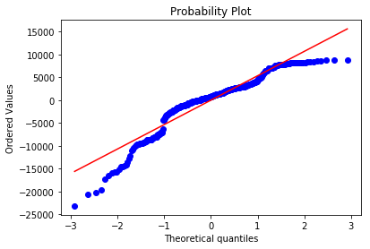

```python
import pylab
import scipy.stats as stats

stats.probplot((fitted2.predict() - y_test), dist="norm", plot=pylab)
pylab.show()
```

#### Q-Q plot to show how residuals lie when comparing the model predictions to the test data. If the predictions were perfect then they would line up along the red line. It can be seen that our residuals are mostly however not aligning.

#### Consulting the R^2 values show the model to do a poorer a job at explaining the overall dependent variable variance (75% < 83%). Along with the plot above, it could be feasible that our linear model contains features whose relationship with charges is non linear. It is possible to manipulate some of the features in order to engineer a more linear relationship, but this can be fairly exhaustive. A decision tree does not have issues with non linear effects and hence is a better predictor. However, our linear model does provide us with some other important information

#### The P-values tell us the level of feature importance (significance) to the overall fit by ways of testing the null hypothesis that the individual coefficients associated with each independent variable are equal to zero. Typically, we can use alpha = 0.05, hence any P-value < 0.05 we can reject the null hypothesis and consider that coefficient to be significant.

#### It can be seen, all but sex have P-values < 0.05, hence all (apart from sex) are important features in the prediction of charges.

# Summary

#### I have analyzed health insurance data in order to train and test various features as predictors of total charges paid by individual customers. Using various models and visualization, I have found that the most important features that predict charges are if clients are smokers or not, BMI, and age, but to a lesser degree, region and the number of children also have an impact. Gender was shown to have not significant impact on overall charges.

#### It is in the best interest for the clients and the insurer that clients quit habits of smoking and to eat healthier. Perhaps as an incentive or product, the insurance company would be inclined to contact clients who are paying large charges to try help them make better everyday life decisions.